# R 實習 4：兩組比較與配對分析

Week 09｜R4

HT3001B 生物統計學與 R

2026-11-05

## 先寫問題，再開啟程式

兩個問題：

1. 母親不吸菸與吸菸兩組，平均出生體重差多少？
2. 同一隻羊的前後改變，與 ESC／對照組的改變差異，回答的是同一問題嗎？

先填研究對象、資料來源、估計量、結構、方法、條件與推論界線。

本週 R 實作；week09_r4.R；R stats 官方文件

## 把檔案放在同一個 Project

下載學生起始 QMD · 完整 R 程式

出生資料 CSV · 綿羊資料 CSV

使用 RStudio Project；另存起始檔為 `week09_lab.qmd`。本週示範使用內建 R 函數。

本週 R 實作；week09_r4.R；R stats 官方文件

## 讀入資料，先看欄位與缺失

```r
births14 <- read.csv("births14.csv", na.strings = c("", "NA"))
names(births14)
head(births14)
table(births14$habit, useNA = "ifany")
```

`weight` 單位是 lb；`habit` 是母親吸菸狀態。原始 1,000 筆，habit 缺失 19 筆。

OpenIntro births14 官方資料說明；本週 R 執行輸出

## 只排除這個問題用到的欄位缺失

```r
keep <- complete.cases(births14[c("weight", "habit")])
births <- births14[keep, ]
births$habit <- factor(births$habit,
                       levels = c("nonsmoker", "smoker"))
table(births$habit)
```

保留 981 筆：867 位不吸菸、114 位吸菸。因子（factor）的層級順序也決定平均差方向。

本週 R 實作；week09_r4.R；R stats 官方文件

## 先用摘要與圖，預測分析會看到什麼

```r
tapply(births$weight, births$habit, mean)
tapply(births$weight, births$habit, sd)
boxplot(weight ~ habit, data = births)
```

請先預測：哪組平均較高？哪組較分散？樣本數相同嗎？

本週 R 實作；week09_r4.R；R stats 官方文件

## 看見個體變異與組間差

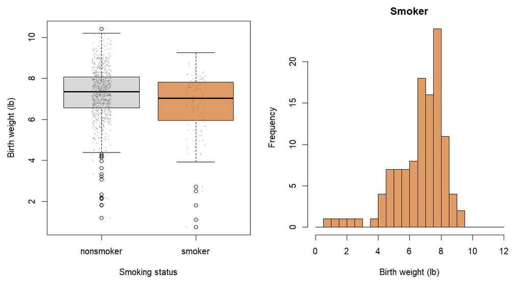

每點是一名新生兒，縱軸為出生體重 lb；右圖為吸菸組分布。

檢查低體重端、組間樣本數與 SD；先記錄圖形判斷。

自製圖；官方 births14；week09_r4.R

## 執行 Welch，讀取輸出

```r
fit <- t.test(weight ~ habit, data = births)
fit
fit$estimate
fit$conf.int
fit$p.value
```

預設 `var.equal = FALSE`。先讀兩組估計值及順序，再讀 t、df、區間與 p。

本週 R 實作；week09_r4.R；R stats 官方文件

## 一份輸出，分開回答三個問題

| 估計 | 結果 |
| --- | --- |
| 不吸菸組／吸菸組平均 | 7.270／6.677 lb |
| 不吸菸減吸菸 | 0.593 lb |
| 95% CI | 0.285–0.900 lb |
| Welch t／df／p | 3.817／131.306／0.000208 |

差的大小、不確定性與對虛無模型的證據，應各自說明。

verification/r4_results.csv

## 用 qt 核對區間

```r
ns <- births$weight[births$habit == "nonsmoker"]
sm <- births$weight[births$habit == "smoker"]
SE <- sqrt(var(ns)/length(ns) + var(sm)/length(sm))
critical <- qt(0.975, df = fit$parameter)
mean(ns) - mean(sm) + c(-1, 1) * critical * SE
```

Welch 自由度由軟體算；此例約 131.3，並非課本保守近似的 113。

本週 R 實作；week09_r4.R；R stats 官方文件

## 把合併 SD 的約定寫進程式

```r
n1 <- length(ns); n2 <- length(sm)
sp <- sqrt(((n1-1)*var(ns) + (n2-1)*var(sm)) /
           (n1+n2-2))
d <- (mean(ns)-mean(sm)) / sp
d
```

本例 d＝0.463；保留原始單位的平均差與 CI，並交代標準化分母。

本週 R 實作；week09_r4.R；R stats 官方文件

## 同一隻羊的前後欄位，保留在同一列

```r
stem_cell <- read.csv("stem_cell.csv")
keep <- complete.cases(stem_cell[c("trmt", "before", "after")])
stem <- stem_cell[keep, ]
stem$change <- stem$after - stem$before
esc <- stem[stem$trmt == "esc", ]
ctrl <- stem[stem$trmt == "ctrl", ]
```

18 隻綿羊隨機分派至 ESC 與對照組，各 9 隻。每列同一隻羊，change 為心臟泵血功能的百分點改變。

OpenIntro stem_cell 官方說明；IMS §20.4

## 每條線保留一隻羊的前後對應

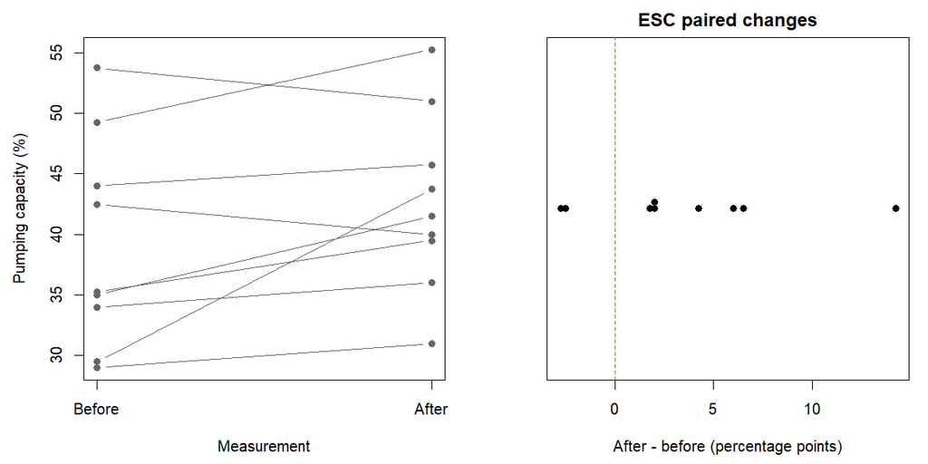

左圖每線為 ESC 組一隻羊；右圖每點為 after−before 的百分點改變。

先看差值分散與最大變化，再比較平均。

自製圖；官方 stem_cell；week09_r4.R

## 配對 t 與差值的單樣本 t 等價

```r
paired <- t.test(esc$after, esc$before, paired = TRUE)
as_diff <- t.test(esc$change)
paired
as_diff
```

平均改變 3.5 百分點；95% CI（−0.476, 7.476），p＝0.07684。兩次呼叫針對相同完整差值。

本週 R 實作；week09_r4.R；R stats 官方文件

## 練習 1｜忘記 paired，改了什麼？

```r
t.test(esc$after, esc$before)
```

先預測自由度與 SE 會否改變，再執行。

此呼叫把兩欄當獨立樣本，沒有保留同一隻羊的相依性。p 約 0.37；應由設計選擇配對，而非由哪個 p 值較小選擇。

本週 R 實作；week09_r4.R；R stats 官方文件

## 治療效果的問題，需要兩組變化量比較

```r
between <- t.test(ctrl$change, esc$change)
between
```

CTRL−ESC 改變差＝−7.833 百分點；95% CI（−12.084, −3.583），p＝0.001678。

ESC 組內平均 +3.5，CTRL 平均 −4.333；組內前後與組間改變回答不同問題。

本週 R 實作；week09_r4.R；R stats 官方文件

## 置換：重新分派標籤，保留結果值

```r
set.seed(1105)
B <- 10000
obs <- mean(ctrl$change) - mean(esc$change)
perm <- replicate(B, {
  g <- sample(stem$trmt)
  mean(stem$change[g=="ctrl"]) - mean(stem$change[g=="esc"])
})
```

本例依隨機分派設計及無個體處理效果假設重排。`sample()` 預設不放回。

本週 R 實作；week09_r4.R；R stats 官方文件

## 模擬 p 值：包含兩尾，交代模擬誤差

```r
k <- sum(abs(perm) >= abs(obs))
p_perm <- (k + 1) / (B + 1)
p_perm
```

本次 10,000 次中 7 次至少同樣極端；plus-one 修正得 p≈0.000800。增加模擬次數可減少 Monte Carlo 誤差，不會增加羊的數量。

本週 R 實作；week09_r4.R；R stats 官方文件

## 把觀察差放回虛無分布

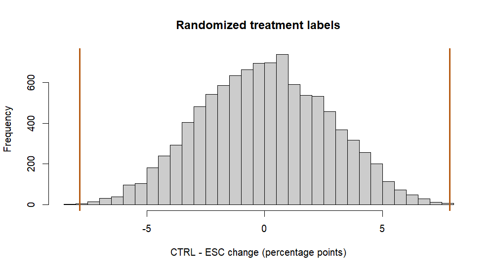

每個模擬平均差由一次合法重排得到；橘線標示 ±|觀察差|。

直接洗牌需要可交換條件；出生資料不能只因兩組平均相等，就任意套用此重排。

自製圖；week09_r4.R；IMS §20.1

## Wilcoxon 短示範：保留資料結構

```r
wilcox.test(weight ~ habit, data = births, exact = FALSE)
wilcox.test(esc$after, esc$before,
            paired = TRUE, exact = FALSE)
```

兩者分別為 rank-sum 與 signed-rank；`exact = FALSE` 採近似計算。先說明估計目標與條件，再解釋輸出。

R stats::wilcox.test；R 4.4.3；本週方法定位

## 用三句話形成完整結論

1. 差多少？固定方向，保留 lb 或百分點。
2. 不確定性多大？報告 CI，再說明檢定結果。
3. 推論到哪裡？出生資料為觀察資料；綿羊試驗不能直接外推成人體效果。

保存程式、圖、計畫修訂與 AI 使用說明；用 QMD 重新執行並產生輸出。

本週 R 實作；week09_r4.R；R stats 官方文件

## 本週繳交：R 作業與分析計畫階段

R 作業：兩組平均差與配對／組間變化量分析，交付 QMD、輸出及方法解釋。

分析計畫：保留分析前七個問題，補方法條件、圖表、預定輸出、查核與替代方案，再附修訂紀錄。

分析計畫沿用自己的研究問題與資料；階段編號、期限及評分依 ee-class 公告。

syllabus_v3；2026-11-04 教師決定

## R4 Quiz｜R 程式題 4–6

每題 45 秒，單選；由課堂啟動本段 Quiz。

[**開啟 Slido 作答頁**](https://app.sli.do/event/1jvhioqZKKM7xUwqNzn4av) · 活動代碼 **2249905**

[figure not shown]

第九週 Slido 作答入口 QR code，活動代碼 2249905。

[第九週 Slido](https://app.sli.do/event/1jvhioqZKKM7xUwqNzn4av)；R4：R 程式題 4–6

## Slido 4｜哪個呼叫保留前後配對？

esc 每列是同一隻羊的完整前後測。哪個呼叫直接分析 after−before 的平均？

1. `t.test(esc$after, esc$before)`
2. `t.test(esc$after, esc$before, paired = TRUE)`
3. `t.test(esc$after, esc$before, var.equal = TRUE)`
4. `t.test(esc$after)`

**答案：B。**paired = TRUE 保留同列配對，等價於對 esc$change 做單樣本 t。

本週已教 R 語法；R stats::t.test / base::sample

## Slido 5｜哪一種抽法符合標籤置換？

x 是六個互不重複的標籤，要重排六個位置並讓每個標籤恰出現一次。哪個呼叫符合？

1. `sample(x, size = 6, replace = TRUE)`
2. `sample(x, size = 1)`
3. `sample(x, size = 6, replace = FALSE)`
4. `replicate(6, mean(x))`

**答案：C。**不放回抽滿六個位置保留每個標籤一次；放回抽樣可能重複或遺漏。

本週已教 R 語法；R stats::t.test / base::sample

## Slido 6｜Welch 的預設與方向

births$habit 的層級依序為 nonsmoker、smoker。執行 t.test(weight ~ habit, data = births)，哪個解釋正確？

1. 預設使用配對 t，方向為前減後
2. 預設合併兩組變異，且 df 一定是 n1+n2−2
3. 預設檢驗兩組中位數差，方向由樣本數決定
4. 預設使用 Welch，差的方向為 nonsmoker 減 smoker

**答案：D。**var.equal = FALSE 是預設；公式方法依分組層級排列兩組，方向要與輸出估計值核對。

本週已教 R 語法；R stats::t.test / base::sample